# Risk Factor Analysis

## Outcome Variable

**Outcome Variable:** whz

## Predictor Variables

**Intervention Variable:** exclfeed3

**Adjustment Set:**

- arm
- sex
- brthmon
- W_mage
- meducyrs
- feducyrs
- hhwealth_quart
- hfoodsec
- W_mhtcm
- W_mwtkg
- W_mbmi
- vagbrth
- W_gagebrth
- W_birthwt
- W_birthlen
- W_nrooms
- W_nchldlt5
- month
- W_parity
- impfloor
- impsan
- safeh20
- delta_W_mage
- delta_meducyrs
- delta_feducyrs
- delta_hhwealth_quart
- delta_hfoodsec
- delta_W_mhtcm
- delta_W_mwtkg
- delta_W_mbmi
- delta_vagbrth
- delta_W_gagebrth
- delta_W_birthwt
- delta_W_birthlen
- delta_W_nrooms
- delta_W_nchldlt5
- delta_month
- delta_W_parity
- delta_impfloor
- delta_impsan
- delta_safeh20

## Stratifying Variables

The analysis was stratified on these variable(s):

- agecat
- studyid
- country

## Data Summary

| agecat | studyid | country | exclfeed3 | n_cell | n |
| --- | --- | --- | --- | --- | --- |
| Birth | ki0047075b-MAL-ED | BANGLADESH | 1 | 130 | 202 |
| Birth | ki0047075b-MAL-ED | BANGLADESH | 0 | 72 | 202 |
| Birth | ki0047075b-MAL-ED | BRAZIL | 1 | 11 | 55 |
| Birth | ki0047075b-MAL-ED | BRAZIL | 0 | 44 | 55 |
| Birth | ki0047075b-MAL-ED | INDIA | 1 | 22 | 39 |
| Birth | ki0047075b-MAL-ED | INDIA | 0 | 17 | 39 |
| Birth | ki0047075b-MAL-ED | NEPAL | 1 | 8 | 25 |
| Birth | ki0047075b-MAL-ED | NEPAL | 0 | 17 | 25 |
| Birth | ki0047075b-MAL-ED | PERU | 1 | 47 | 218 |
| Birth | ki0047075b-MAL-ED | PERU | 0 | 171 | 218 |
| Birth | ki0047075b-MAL-ED | SOUTH AFRICA | 1 | 12 | 99 |
| Birth | ki0047075b-MAL-ED | SOUTH AFRICA | 0 | 87 | 99 |
| Birth | ki0047075b-MAL-ED | TANZANIA, UNITED REPUBLIC OF | 1 | 15 | 95 |
| Birth | ki0047075b-MAL-ED | TANZANIA, UNITED REPUBLIC OF | 0 | 80 | 95 |
| Birth | ki1000108-CMC-V-BCS-2002 | INDIA | 1 | 4 | 4 |
| Birth | ki1000108-CMC-V-BCS-2002 | INDIA | 0 | 0 | 4 |
| Birth | ki1000108-IRC | INDIA | 1 | 0 | 9 |
| Birth | ki1000108-IRC | INDIA | 0 | 9 | 9 |
| Birth | ki1000109-EE | PAKISTAN | 1 | 22 | 22 |
| Birth | ki1000109-EE | PAKISTAN | 0 | 0 | 22 |
| Birth | ki1000304b-SAS-CompFeed | INDIA | 1 | 310 | 325 |
| Birth | ki1000304b-SAS-CompFeed | INDIA | 0 | 15 | 325 |
| Birth | ki1017093b-PROVIDE | BANGLADESH | 1 | 381 | 532 |
| Birth | ki1017093b-PROVIDE | BANGLADESH | 0 | 151 | 532 |
| Birth | ki1101329-Keneba | GAMBIA | 1 | 1133 | 1282 |
| Birth | ki1101329-Keneba | GAMBIA | 0 | 149 | 1282 |
| Birth | ki1113344-GMS-Nepal | NEPAL | 1 | 352 | 422 |
| Birth | ki1113344-GMS-Nepal | NEPAL | 0 | 70 | 422 |
| Birth | kiGH5241-JiVitA-3 | BANGLADESH | 1 | 9636 | 10634 |
| Birth | kiGH5241-JiVitA-3 | BANGLADESH | 0 | 998 | 10634 |

[output cut: 64 more lines]

The following strata were considered:

- agecat: 24 months, studyid: ki0047075b-MAL-ED, country: BANGLADESH
- agecat: 24 months, studyid: ki0047075b-MAL-ED, country: BRAZIL
- agecat: 24 months, studyid: ki0047075b-MAL-ED, country: INDIA
- agecat: 24 months, studyid: ki0047075b-MAL-ED, country: NEPAL
- agecat: 24 months, studyid: ki0047075b-MAL-ED, country: PERU
- agecat: 24 months, studyid: ki0047075b-MAL-ED, country: SOUTH AFRICA
- agecat: 24 months, studyid: ki0047075b-MAL-ED, country: TANZANIA, UNITED REPUBLIC OF
- agecat: 24 months, studyid: ki1000108-CMC-V-BCS-2002, country: INDIA
- agecat: 24 months, studyid: ki1000108-IRC, country: INDIA
- agecat: 24 months, studyid: ki1000109-EE, country: PAKISTAN
- agecat: 24 months, studyid: ki1017093b-PROVIDE, country: BANGLADESH
- agecat: 24 months, studyid: ki1101329-Keneba, country: GAMBIA
- agecat: 24 months, studyid: ki1113344-GMS-Nepal, country: NEPAL
- agecat: 24 months, studyid: kiGH5241-JiVitA-3, country: BANGLADESH
- agecat: 24 months, studyid: kiGH5241-JiVitA-4, country: BANGLADESH
- agecat: 6 months, studyid: ki0047075b-MAL-ED, country: BANGLADESH
- agecat: 6 months, studyid: ki0047075b-MAL-ED, country: BRAZIL
- agecat: 6 months, studyid: ki0047075b-MAL-ED, country: INDIA
- agecat: 6 months, studyid: ki0047075b-MAL-ED, country: NEPAL
- agecat: 6 months, studyid: ki0047075b-MAL-ED, country: PERU
- agecat: 6 months, studyid: ki0047075b-MAL-ED, country: SOUTH AFRICA
- agecat: 6 months, studyid: ki0047075b-MAL-ED, country: TANZANIA, UNITED REPUBLIC OF
- agecat: 6 months, studyid: ki1000108-CMC-V-BCS-2002, country: INDIA
- agecat: 6 months, studyid: ki1000108-IRC, country: INDIA
- agecat: 6 months, studyid: ki1000109-EE, country: PAKISTAN
- agecat: 6 months, studyid: ki1000304b-SAS-CompFeed, country: INDIA
- agecat: 6 months, studyid: ki1017093b-PROVIDE, country: BANGLADESH
- agecat: 6 months, studyid: ki1101329-Keneba, country: GAMBIA
- agecat: 6 months, studyid: ki1113344-GMS-Nepal, country: NEPAL
- agecat: 6 months, studyid: kiGH5241-JiVitA-3, country: BANGLADESH
- agecat: 6 months, studyid: kiGH5241-JiVitA-4, country: BANGLADESH
- agecat: Birth, studyid: ki0047075b-MAL-ED, country: BANGLADESH
- agecat: Birth, studyid: ki0047075b-MAL-ED, country: BRAZIL
- agecat: Birth, studyid: ki0047075b-MAL-ED, country: INDIA
- agecat: Birth, studyid: ki0047075b-MAL-ED, country: NEPAL
- agecat: Birth, studyid: ki0047075b-MAL-ED, country: PERU
- agecat: Birth, studyid: ki0047075b-MAL-ED, country: SOUTH AFRICA
- agecat: Birth, studyid: ki0047075b-MAL-ED, country: TANZANIA, UNITED REPUBLIC OF
- agecat: Birth, studyid: ki1000108-CMC-V-BCS-2002, country: INDIA
- agecat: Birth, studyid: ki1000108-IRC, country: INDIA
- agecat: Birth, studyid: ki1000109-EE, country: PAKISTAN
- agecat: Birth, studyid: ki1000304b-SAS-CompFeed, country: INDIA
- agecat: Birth, studyid: ki1017093b-PROVIDE, country: BANGLADESH
- agecat: Birth, studyid: ki1101329-Keneba, country: GAMBIA
- agecat: Birth, studyid: ki1113344-GMS-Nepal, country: NEPAL
- agecat: Birth, studyid: kiGH5241-JiVitA-3, country: BANGLADESH
- agecat: Birth, studyid: kiGH5241-JiVitA-4, country: BANGLADESH

### Dropped Strata

- agecat: Birth, studyid: ki1000108-CMC-V-BCS-2002, country: INDIA
- agecat: Birth, studyid: ki1000108-IRC, country: INDIA
- agecat: Birth, studyid: ki1000109-EE, country: PAKISTAN
- agecat: 6 months, studyid: ki1000108-CMC-V-BCS-2002, country: INDIA
- agecat: 6 months, studyid: ki1000108-IRC, country: INDIA
- agecat: 6 months, studyid: ki1000109-EE, country: PAKISTAN
- agecat: 24 months, studyid: ki1000108-CMC-V-BCS-2002, country: INDIA
- agecat: 24 months, studyid: ki1000108-IRC, country: INDIA
- agecat: 24 months, studyid: ki1000109-EE, country: PAKISTAN

## Methods Detail

We’re interested in the causal parameters $E[Y_a]$ for all values of $a \in \mathcal{A}$. These parameters represent the mean outcome if, possibly contrary to fact, we intervened to set all units to have $A=a$. Under the randomization and positivity assumptions, these are identified by the statistical parameters $\psi_a=E_W[E_{Y|A,W}(Y|A=a,W)]$. In addition, we’re interested in the mean of $Y$, $E[Y]$ under no intervention (the observed mean). We will estimate these parameters by using SuperLearner to fit the relevant likelihood factors – $E_{Y|A,W}(Y|A=a,W)$ and $p(A=a|W)$, and then updating our likelihood fit using a joint TMLE.

For unadjusted analyses ($W=\{\}$), initial likelihoods were estimated using Lrnr_glm to estimate the simple $E(Y|A)$ and Lrnr_mean to estimate $p(A)$. For adjusted analyses, a small library containing Lrnr_glmnet, Lrnr_xgboost, and Lrnr_mean was used.

Having estimated these parameters, we will then use the delta method to estimate relative risks and attributable risks relative to a prespecified baseline level of $A$.

# Results Detail

## Results Plots

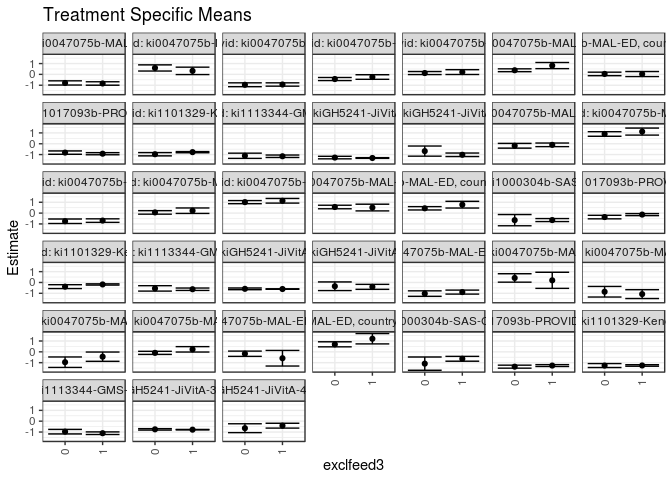

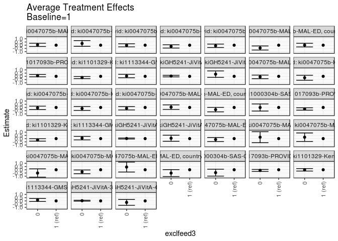

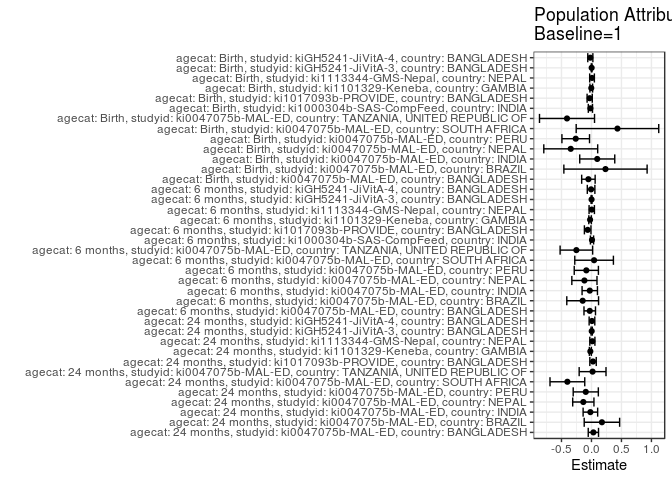

## Results Table

### Parameter: TSM

| agecat | studyid | country | intervention_level | baseline_level | estimate | ci_lower | ci_upper |
| --- | --- | --- | --- | --- | --- | --- | --- |
| Birth | ki0047075b-MAL-ED | BANGLADESH | 1 | NA | -0.8901839 | -1.0750910 | -0.7052768 |
| Birth | ki0047075b-MAL-ED | BANGLADESH | 0 | NA | -1.0267359 | -1.2799981 | -0.7734737 |
| Birth | ki0047075b-MAL-ED | BRAZIL | 1 | NA | 0.1978412 | -0.5450284 | 0.9407109 |
| Birth | ki0047075b-MAL-ED | BRAZIL | 0 | NA | 0.4171331 | 0.0274369 | 0.8068293 |
| Birth | ki0047075b-MAL-ED | INDIA | 1 | NA | -1.0742458 | -1.4841101 | -0.6643815 |
| Birth | ki0047075b-MAL-ED | INDIA | 0 | NA | -0.8558799 | -1.3466755 | -0.3650843 |
| Birth | ki0047075b-MAL-ED | NEPAL | 1 | NA | -0.4487500 | -0.8783289 | -0.0191711 |
| Birth | ki0047075b-MAL-ED | NEPAL | 0 | NA | -0.9570588 | -1.4394884 | -0.4746293 |
| Birth | ki0047075b-MAL-ED | PERU | 1 | NA | 0.2290287 | -0.0205967 | 0.4786540 |
| Birth | ki0047075b-MAL-ED | PERU | 0 | NA | -0.0950065 | -0.2380473 | 0.0480342 |
| Birth | ki0047075b-MAL-ED | SOUTH AFRICA | 1 | NA | -0.5923969 | -1.3125009 | 0.1277071 |
| Birth | ki0047075b-MAL-ED | SOUTH AFRICA | 0 | NA | -0.1755237 | -0.4192785 | 0.0682311 |
| Birth | ki0047075b-MAL-ED | TANZANIA, UNITED REPUBLIC OF | 1 | NA | 1.2075048 | 0.7304535 | 1.6845561 |
| Birth | ki0047075b-MAL-ED | TANZANIA, UNITED REPUBLIC OF | 0 | NA | 0.6925216 | 0.4589097 | 0.9261335 |
| Birth | ki1000304b-SAS-CompFeed | INDIA | 1 | NA | -0.6419787 | -0.8661092 | -0.4178481 |
| Birth | ki1000304b-SAS-CompFeed | INDIA | 0 | NA | -1.0901282 | -1.7027393 | -0.4775170 |
| Birth | ki1017093b-PROVIDE | BANGLADESH | 1 | NA | -1.2688269 | -1.3555947 | -1.1820590 |
| Birth | ki1017093b-PROVIDE | BANGLADESH | 0 | NA | -1.3706781 | -1.5094337 | -1.2319226 |
| Birth | ki1101329-Keneba | GAMBIA | 1 | NA | -1.2596870 | -1.3277458 | -1.1916282 |
| Birth | ki1101329-Keneba | GAMBIA | 0 | NA | -1.2671613 | -1.4507800 | -1.0835425 |
| Birth | ki1113344-GMS-Nepal | NEPAL | 1 | NA | -1.1084940 | -1.2274621 | -0.9895259 |
| Birth | ki1113344-GMS-Nepal | NEPAL | 0 | NA | -0.9672348 | -1.1771068 | -0.7573627 |
| Birth | kiGH5241-JiVitA-3 | BANGLADESH | 1 | NA | -0.7829486 | -0.8061917 | -0.7597056 |
| Birth | kiGH5241-JiVitA-3 | BANGLADESH | 0 | NA | -0.7523629 | -0.8191030 | -0.6856227 |
| Birth | kiGH5241-JiVitA-4 | BANGLADESH | 1 | NA | -0.4156180 | -0.6383645 | -0.1928714 |
| Birth | kiGH5241-JiVitA-4 | BANGLADESH | 0 | NA | -0.6475000 | -1.0569566 | -0.2380434 |
| 6 months | ki0047075b-MAL-ED | BANGLADESH | 1 | NA | -0.1016807 | -0.2679938 | 0.0646323 |
| 6 months | ki0047075b-MAL-ED | BANGLADESH | 0 | NA | -0.1860837 | -0.4049606 | 0.0327932 |
| 6 months | ki0047075b-MAL-ED | BRAZIL | 1 | NA | 1.1220892 | 0.7965866 | 1.4475917 |
| 6 months | ki0047075b-MAL-ED | BRAZIL | 0 | NA | 0.9009142 | 0.6907830 | 1.1110454 |
| 6 months | ki0047075b-MAL-ED | INDIA | 1 | NA | -0.6901993 | -0.8537130 | -0.5266855 |
| 6 months | ki0047075b-MAL-ED | INDIA | 0 | NA | -0.7514064 | -0.9589361 | -0.5438767 |
| 6 months | ki0047075b-MAL-ED | NEPAL | 1 | NA | 0.2218659 | -0.0304267 | 0.4741585 |
| 6 months | ki0047075b-MAL-ED | NEPAL | 0 | NA | 0.0633330 | -0.0992257 | 0.2258918 |
| 6 months | ki0047075b-MAL-ED | PERU | 1 | NA | 1.1371622 | 0.9221209 | 1.3522035 |
| 6 months | ki0047075b-MAL-ED | PERU | 0 | NA | 1.0126297 | 0.8675190 | 1.1577403 |
| 6 months | ki0047075b-MAL-ED | SOUTH AFRICA | 1 | NA | 0.5126585 | 0.2025124 | 0.8228046 |
| 6 months | ki0047075b-MAL-ED | SOUTH AFRICA | 0 | NA | 0.5639384 | 0.4006337 | 0.7272431 |
| 6 months | ki0047075b-MAL-ED | TANZANIA, UNITED REPUBLIC OF | 1 | NA | 0.7772944 | 0.4687501 | 1.0858387 |
| 6 months | ki0047075b-MAL-ED | TANZANIA, UNITED REPUBLIC OF | 0 | NA | 0.4434521 | 0.2896911 | 0.5972131 |
| 6 months | ki1000304b-SAS-CompFeed | INDIA | 1 | NA | -0.6438016 | -0.7819173 | -0.5056859 |
| 6 months | ki1000304b-SAS-CompFeed | INDIA | 0 | NA | -0.6500492 | -1.1672739 | -0.1328245 |
| 6 months | ki1017093b-PROVIDE | BANGLADESH | 1 | NA | -0.1359229 | -0.2298907 | -0.0419551 |
| 6 months | ki1017093b-PROVIDE | BANGLADESH | 0 | NA | -0.3647221 | -0.5278625 | -0.2015817 |
| 6 months | ki1101329-Keneba | GAMBIA | 1 | NA | -0.1825770 | -0.2409058 | -0.1242482 |
| 6 months | ki1101329-Keneba | GAMBIA | 0 | NA | -0.3856582 | -0.5635629 | -0.2077535 |
| 6 months | ki1113344-GMS-Nepal | NEPAL | 1 | NA | -0.6245224 | -0.7345421 | -0.5145027 |
| 6 months | ki1113344-GMS-Nepal | NEPAL | 0 | NA | -0.5481045 | -0.7959789 | -0.3002301 |
| 6 months | kiGH5241-JiVitA-3 | BANGLADESH | 1 | NA | -0.6057353 | -0.6313144 | -0.5801561 |
| 6 months | kiGH5241-JiVitA-3 | BANGLADESH | 0 | NA | -0.5876973 | -0.6649165 | -0.5104782 |
| 6 months | kiGH5241-JiVitA-4 | BANGLADESH | 1 | NA | -0.4046986 | -0.6330986 | -0.1762985 |
| 6 months | kiGH5241-JiVitA-4 | BANGLADESH | 0 | NA | -0.3493601 | -0.7469383 | 0.0482182 |
| 24 months | ki0047075b-MAL-ED | BANGLADESH | 1 | NA | -0.8395792 | -0.9980808 | -0.6810775 |
| 24 months | ki0047075b-MAL-ED | BANGLADESH | 0 | NA | -0.7895392 | -0.9823155 | -0.5967629 |
| 24 months | ki0047075b-MAL-ED | BRAZIL | 1 | NA | 0.3238487 | -0.0185472 | 0.6662445 |
| 24 months | ki0047075b-MAL-ED | BRAZIL | 0 | NA | 0.5938412 | 0.3088514 | 0.8788309 |
| 24 months | ki0047075b-MAL-ED | INDIA | 1 | NA | -0.9336727 | -1.0859143 | -0.7814311 |
| 24 months | ki0047075b-MAL-ED | INDIA | 0 | NA | -0.9584556 | -1.1385983 | -0.7783129 |
| 24 months | ki0047075b-MAL-ED | NEPAL | 1 | NA | -0.2432496 | -0.4534114 | -0.0330878 |
| 24 months | ki0047075b-MAL-ED | NEPAL | 0 | NA | -0.4296284 | -0.5701627 | -0.2890941 |
| 24 months | ki0047075b-MAL-ED | PERU | 1 | NA | 0.2126296 | -0.0097548 | 0.4350140 |
| 24 months | ki0047075b-MAL-ED | PERU | 0 | NA | 0.1236237 | -0.0167318 | 0.2639792 |
| 24 months | ki0047075b-MAL-ED | SOUTH AFRICA | 1 | NA | 0.8138813 | 0.5293253 | 1.0984372 |
| 24 months | ki0047075b-MAL-ED | SOUTH AFRICA | 0 | NA | 0.3819136 | 0.2515669 | 0.5122604 |
| 24 months | ki0047075b-MAL-ED | TANZANIA, UNITED REPUBLIC OF | 1 | NA | 0.0308800 | -0.2013351 | 0.2630952 |
| 24 months | ki0047075b-MAL-ED | TANZANIA, UNITED REPUBLIC OF | 0 | NA | 0.0428733 | -0.1171859 | 0.2029325 |
| 24 months | ki1017093b-PROVIDE | BANGLADESH | 1 | NA | -0.9190853 | -1.0155449 | -0.8226257 |
| 24 months | ki1017093b-PROVIDE | BANGLADESH | 0 | NA | -0.8175060 | -0.9720066 | -0.6630054 |
| 24 months | ki1101329-Keneba | GAMBIA | 1 | NA | -0.7744333 | -0.8287044 | -0.7201623 |
| 24 months | ki1101329-Keneba | GAMBIA | 0 | NA | -0.9676565 | -1.1185482 | -0.8167648 |
| 24 months | ki1113344-GMS-Nepal | NEPAL | 1 | NA | -1.1545036 | -1.2669596 | -1.0420475 |
| 24 months | ki1113344-GMS-Nepal | NEPAL | 0 | NA | -1.1093838 | -1.3497274 | -0.8690403 |
| 24 months | kiGH5241-JiVitA-3 | BANGLADESH | 1 | NA | -1.3148336 | -1.3466335 | -1.2830337 |
| 24 months | kiGH5241-JiVitA-3 | BANGLADESH | 0 | NA | -1.2762928 | -1.3940661 | -1.1585195 |
| 24 months | kiGH5241-JiVitA-4 | BANGLADESH | 1 | NA | -1.0179245 | -1.1805622 | -0.8552868 |
| 24 months | kiGH5241-JiVitA-4 | BANGLADESH | 0 | NA | -0.6804506 | -1.1482896 | -0.2126116 |

### Parameter: E(Y)

| agecat | studyid | country | intervention_level | baseline_level | estimate | ci_lower | ci_upper |
| --- | --- | --- | --- | --- | --- | --- | --- |
| Birth | ki0047075b-MAL-ED | BANGLADESH | NA | NA | -0.9411386 | -1.0895370 | -0.7927402 |
| Birth | ki0047075b-MAL-ED | BRAZIL | NA | NA | 0.4316364 | 0.0969688 | 0.7663039 |
| Birth | ki0047075b-MAL-ED | INDIA | NA | NA | -0.9779487 | -1.2664810 | -0.6894164 |
| Birth | ki0047075b-MAL-ED | NEPAL | NA | NA | -0.7944000 | -1.1625222 | -0.4262778 |
| Birth | ki0047075b-MAL-ED | PERU | NA | NA | -0.0335321 | -0.1564905 | 0.0894263 |
| Birth | ki0047075b-MAL-ED | SOUTH AFRICA | NA | NA | -0.1588889 | -0.3845288 | 0.0667510 |
| Birth | ki0047075b-MAL-ED | TANZANIA, UNITED REPUBLIC OF | NA | NA | 0.7996842 | 0.5874808 | 1.0118876 |
| Birth | ki1000304b-SAS-CompFeed | INDIA | NA | NA | -0.6596308 | -0.9005716 | -0.4186900 |
| Birth | ki1017093b-PROVIDE | BANGLADESH | NA | NA | -1.2984586 | -1.3752758 | -1.2216415 |
| Birth | ki1101329-Keneba | GAMBIA | NA | NA | -1.2629563 | -1.3291505 | -1.1967622 |
| Birth | ki1113344-GMS-Nepal | NEPAL | NA | NA | -1.0991706 | -1.2073693 | -0.9909719 |
| Birth | kiGH5241-JiVitA-3 | BANGLADESH | NA | NA | -0.7798636 | -0.8022140 | -0.7575133 |
| Birth | kiGH5241-JiVitA-4 | BANGLADESH | NA | NA | -0.4347423 | -0.6441144 | -0.2253701 |
| 6 months | ki0047075b-MAL-ED | BANGLADESH | NA | NA | -0.1304936 | -0.2625419 | 0.0015547 |
| 6 months | ki0047075b-MAL-ED | BRAZIL | NA | NA | 0.9754144 | 0.7990651 | 1.1517638 |
| 6 months | ki0047075b-MAL-ED | INDIA | NA | NA | -0.7185992 | -0.8491469 | -0.5880515 |
| 6 months | ki0047075b-MAL-ED | NEPAL | NA | NA | 0.1041483 | -0.0311352 | 0.2394318 |
| 6 months | ki0047075b-MAL-ED | PERU | NA | NA | 1.0514136 | 0.9289176 | 1.1739096 |
| 6 months | ki0047075b-MAL-ED | SOUTH AFRICA | NA | NA | 0.5564071 | 0.4055220 | 0.7072922 |
| 6 months | ki0047075b-MAL-ED | TANZANIA, UNITED REPUBLIC OF | NA | NA | 0.5257626 | 0.3871543 | 0.6643709 |
| 6 months | ki1000304b-SAS-CompFeed | INDIA | NA | NA | -0.6348861 | -0.7630511 | -0.5067211 |
| 6 months | ki1017093b-PROVIDE | BANGLADESH | NA | NA | -0.1990907 | -0.2817968 | -0.1163845 |
| 6 months | ki1101329-Keneba | GAMBIA | NA | NA | -0.2057183 | -0.2614359 | -0.1500006 |
| 6 months | ki1113344-GMS-Nepal | NEPAL | NA | NA | -0.6198791 | -0.7206518 | -0.5191063 |
| 6 months | kiGH5241-JiVitA-3 | BANGLADESH | NA | NA | -0.6040977 | -0.6286619 | -0.5795335 |
| 6 months | kiGH5241-JiVitA-4 | BANGLADESH | NA | NA | -0.4110227 | -0.6122701 | -0.2097753 |
| 24 months | ki0047075b-MAL-ED | BANGLADESH | NA | NA | -0.8076829 | -0.9296166 | -0.6857493 |
| 24 months | ki0047075b-MAL-ED | BRAZIL | NA | NA | 0.4981140 | 0.2760418 | 0.7201863 |
| 24 months | ki0047075b-MAL-ED | INDIA | NA | NA | -0.9516832 | -1.0703961 | -0.8329703 |
| 24 months | ki0047075b-MAL-ED | NEPAL | NA | NA | -0.3790455 | -0.4958857 | -0.2622052 |
| 24 months | ki0047075b-MAL-ED | PERU | NA | NA | 0.1176052 | -0.0015211 | 0.2367315 |
| 24 months | ki0047075b-MAL-ED | SOUTH AFRICA | NA | NA | 0.4120797 | 0.2900939 | 0.5340654 |
| 24 months | ki0047075b-MAL-ED | TANZANIA, UNITED REPUBLIC OF | NA | NA | 0.0495743 | -0.0857535 | 0.1849021 |
| 24 months | ki1017093b-PROVIDE | BANGLADESH | NA | NA | -0.8928670 | -0.9755153 | -0.8102187 |
| 24 months | ki1101329-Keneba | GAMBIA | NA | NA | -0.7930925 | -0.8442611 | -0.7419240 |
| 24 months | ki1113344-GMS-Nepal | NEPAL | NA | NA | -1.1396441 | -1.2416403 | -1.0376479 |
| 24 months | kiGH5241-JiVitA-3 | BANGLADESH | NA | NA | -1.3109518 | -1.3423299 | -1.2795737 |
| 24 months | kiGH5241-JiVitA-4 | BANGLADESH | NA | NA | -1.0096000 | -1.1619164 | -0.8572836 |

### Parameter: ATE

| agecat | studyid | country | intervention_level | baseline_level | estimate | ci_lower | ci_upper |
| --- | --- | --- | --- | --- | --- | --- | --- |
| Birth | ki0047075b-MAL-ED | BANGLADESH | 1 | 1 | 0.0000000 | 0.0000000 | 0.0000000 |
| Birth | ki0047075b-MAL-ED | BANGLADESH | 0 | 1 | -0.1365520 | -0.4516068 | 0.1785027 |
| Birth | ki0047075b-MAL-ED | BRAZIL | 1 | 1 | 0.0000000 | 0.0000000 | 0.0000000 |
| Birth | ki0047075b-MAL-ED | BRAZIL | 0 | 1 | 0.2192919 | -0.6312861 | 1.0698699 |
| Birth | ki0047075b-MAL-ED | INDIA | 1 | 1 | 0.0000000 | 0.0000000 | 0.0000000 |
| Birth | ki0047075b-MAL-ED | INDIA | 0 | 1 | 0.2183659 | -0.4419900 | 0.8787217 |
| Birth | ki0047075b-MAL-ED | NEPAL | 1 | 1 | 0.0000000 | 0.0000000 | 0.0000000 |
| Birth | ki0047075b-MAL-ED | NEPAL | 0 | 1 | -0.5083088 | -1.1542781 | 0.1376604 |
| Birth | ki0047075b-MAL-ED | PERU | 1 | 1 | 0.0000000 | 0.0000000 | 0.0000000 |
| Birth | ki0047075b-MAL-ED | PERU | 0 | 1 | -0.3240352 | -0.6140436 | -0.0340268 |
| Birth | ki0047075b-MAL-ED | SOUTH AFRICA | 1 | 1 | 0.0000000 | 0.0000000 | 0.0000000 |
| Birth | ki0047075b-MAL-ED | SOUTH AFRICA | 0 | 1 | 0.4168732 | -0.3488851 | 1.1826315 |
| Birth | ki0047075b-MAL-ED | TANZANIA, UNITED REPUBLIC OF | 1 | 1 | 0.0000000 | 0.0000000 | 0.0000000 |
| Birth | ki0047075b-MAL-ED | TANZANIA, UNITED REPUBLIC OF | 0 | 1 | -0.5149832 | -1.0489002 | 0.0189338 |
| Birth | ki1000304b-SAS-CompFeed | INDIA | 1 | 1 | 0.0000000 | 0.0000000 | 0.0000000 |
| Birth | ki1000304b-SAS-CompFeed | INDIA | 0 | 1 | -0.4481495 | -0.9783682 | 0.0820692 |
| Birth | ki1017093b-PROVIDE | BANGLADESH | 1 | 1 | 0.0000000 | 0.0000000 | 0.0000000 |
| Birth | ki1017093b-PROVIDE | BANGLADESH | 0 | 1 | -0.1018513 | -0.2571165 | 0.0534140 |
| Birth | ki1101329-Keneba | GAMBIA | 1 | 1 | 0.0000000 | 0.0000000 | 0.0000000 |
| Birth | ki1101329-Keneba | GAMBIA | 0 | 1 | -0.0074743 | -0.1960743 | 0.1811257 |
| Birth | ki1113344-GMS-Nepal | NEPAL | 1 | 1 | 0.0000000 | 0.0000000 | 0.0000000 |
| Birth | ki1113344-GMS-Nepal | NEPAL | 0 | 1 | 0.1412592 | -0.0913322 | 0.3738507 |
| Birth | kiGH5241-JiVitA-3 | BANGLADESH | 1 | 1 | 0.0000000 | 0.0000000 | 0.0000000 |
| Birth | kiGH5241-JiVitA-3 | BANGLADESH | 0 | 1 | 0.0305858 | -0.0385569 | 0.0997284 |
| Birth | kiGH5241-JiVitA-4 | BANGLADESH | 1 | 1 | 0.0000000 | 0.0000000 | 0.0000000 |
| Birth | kiGH5241-JiVitA-4 | BANGLADESH | 0 | 1 | -0.2318820 | -0.6871466 | 0.2233826 |
| 6 months | ki0047075b-MAL-ED | BANGLADESH | 1 | 1 | 0.0000000 | 0.0000000 | 0.0000000 |
| 6 months | ki0047075b-MAL-ED | BANGLADESH | 0 | 1 | -0.0844030 | -0.3600347 | 0.1912287 |
| 6 months | ki0047075b-MAL-ED | BRAZIL | 1 | 1 | 0.0000000 | 0.0000000 | 0.0000000 |
| 6 months | ki0047075b-MAL-ED | BRAZIL | 0 | 1 | -0.2211749 | -0.6082870 | 0.1659371 |
| 6 months | ki0047075b-MAL-ED | INDIA | 1 | 1 | 0.0000000 | 0.0000000 | 0.0000000 |
| 6 months | ki0047075b-MAL-ED | INDIA | 0 | 1 | -0.0612071 | -0.3269669 | 0.2045526 |
| 6 months | ki0047075b-MAL-ED | NEPAL | 1 | 1 | 0.0000000 | 0.0000000 | 0.0000000 |
| 6 months | ki0047075b-MAL-ED | NEPAL | 0 | 1 | -0.1585329 | -0.4583281 | 0.1412623 |
| 6 months | ki0047075b-MAL-ED | PERU | 1 | 1 | 0.0000000 | 0.0000000 | 0.0000000 |
| 6 months | ki0047075b-MAL-ED | PERU | 0 | 1 | -0.1245325 | -0.3838498 | 0.1347848 |
| 6 months | ki0047075b-MAL-ED | SOUTH AFRICA | 1 | 1 | 0.0000000 | 0.0000000 | 0.0000000 |
| 6 months | ki0047075b-MAL-ED | SOUTH AFRICA | 0 | 1 | 0.0512799 | -0.2990192 | 0.4015789 |
| 6 months | ki0047075b-MAL-ED | TANZANIA, UNITED REPUBLIC OF | 1 | 1 | 0.0000000 | 0.0000000 | 0.0000000 |
| 6 months | ki0047075b-MAL-ED | TANZANIA, UNITED REPUBLIC OF | 0 | 1 | -0.3338423 | -0.6790552 | 0.0113706 |
| 6 months | ki1000304b-SAS-CompFeed | INDIA | 1 | 1 | 0.0000000 | 0.0000000 | 0.0000000 |
| 6 months | ki1000304b-SAS-CompFeed | INDIA | 0 | 1 | -0.0062476 | -0.5560776 | 0.5435824 |
| 6 months | ki1017093b-PROVIDE | BANGLADESH | 1 | 1 | 0.0000000 | 0.0000000 | 0.0000000 |
| 6 months | ki1017093b-PROVIDE | BANGLADESH | 0 | 1 | -0.2287992 | -0.4156319 | -0.0419664 |
| 6 months | ki1101329-Keneba | GAMBIA | 1 | 1 | 0.0000000 | 0.0000000 | 0.0000000 |
| 6 months | ki1101329-Keneba | GAMBIA | 0 | 1 | -0.2030812 | -0.3896540 | -0.0165084 |
| 6 months | ki1113344-GMS-Nepal | NEPAL | 1 | 1 | 0.0000000 | 0.0000000 | 0.0000000 |
| 6 months | ki1113344-GMS-Nepal | NEPAL | 0 | 1 | 0.0764179 | -0.1937634 | 0.3465992 |
| 6 months | kiGH5241-JiVitA-3 | BANGLADESH | 1 | 1 | 0.0000000 | 0.0000000 | 0.0000000 |
| 6 months | kiGH5241-JiVitA-3 | BANGLADESH | 0 | 1 | 0.0180379 | -0.0623537 | 0.0984296 |
| 6 months | kiGH5241-JiVitA-4 | BANGLADESH | 1 | 1 | 0.0000000 | 0.0000000 | 0.0000000 |
| 6 months | kiGH5241-JiVitA-4 | BANGLADESH | 0 | 1 | 0.0553385 | -0.4147761 | 0.5254531 |
| 24 months | ki0047075b-MAL-ED | BANGLADESH | 1 | 1 | 0.0000000 | 0.0000000 | 0.0000000 |
| 24 months | ki0047075b-MAL-ED | BANGLADESH | 0 | 1 | 0.0500400 | -0.2000929 | 0.3001728 |
| 24 months | ki0047075b-MAL-ED | BRAZIL | 1 | 1 | 0.0000000 | 0.0000000 | 0.0000000 |
| 24 months | ki0047075b-MAL-ED | BRAZIL | 0 | 1 | 0.2699925 | -0.1764836 | 0.7164686 |
| 24 months | ki0047075b-MAL-ED | INDIA | 1 | 1 | 0.0000000 | 0.0000000 | 0.0000000 |
| 24 months | ki0047075b-MAL-ED | INDIA | 0 | 1 | -0.0247829 | -0.2618886 | 0.2123227 |
| 24 months | ki0047075b-MAL-ED | NEPAL | 1 | 1 | 0.0000000 | 0.0000000 | 0.0000000 |
| 24 months | ki0047075b-MAL-ED | NEPAL | 0 | 1 | -0.1863788 | -0.4390393 | 0.0662816 |
| 24 months | ki0047075b-MAL-ED | PERU | 1 | 1 | 0.0000000 | 0.0000000 | 0.0000000 |
| 24 months | ki0047075b-MAL-ED | PERU | 0 | 1 | -0.0890059 | -0.3538635 | 0.1758518 |
| 24 months | ki0047075b-MAL-ED | SOUTH AFRICA | 1 | 1 | 0.0000000 | 0.0000000 | 0.0000000 |
| 24 months | ki0047075b-MAL-ED | SOUTH AFRICA | 0 | 1 | -0.4319676 | -0.7459105 | -0.1180248 |
| 24 months | ki0047075b-MAL-ED | TANZANIA, UNITED REPUBLIC OF | 1 | 1 | 0.0000000 | 0.0000000 | 0.0000000 |
| 24 months | ki0047075b-MAL-ED | TANZANIA, UNITED REPUBLIC OF | 0 | 1 | 0.0119933 | -0.2697019 | 0.2936884 |
| 24 months | ki1017093b-PROVIDE | BANGLADESH | 1 | 1 | 0.0000000 | 0.0000000 | 0.0000000 |
| 24 months | ki1017093b-PROVIDE | BANGLADESH | 0 | 1 | 0.1015793 | -0.0793103 | 0.2824689 |
| 24 months | ki1101329-Keneba | GAMBIA | 1 | 1 | 0.0000000 | 0.0000000 | 0.0000000 |
| 24 months | ki1101329-Keneba | GAMBIA | 0 | 1 | -0.1932232 | -0.3535838 | -0.0328625 |
| 24 months | ki1113344-GMS-Nepal | NEPAL | 1 | 1 | 0.0000000 | 0.0000000 | 0.0000000 |
| 24 months | ki1113344-GMS-Nepal | NEPAL | 0 | 1 | 0.0451197 | -0.2202855 | 0.3105249 |
| 24 months | kiGH5241-JiVitA-3 | BANGLADESH | 1 | 1 | 0.0000000 | 0.0000000 | 0.0000000 |
| 24 months | kiGH5241-JiVitA-3 | BANGLADESH | 0 | 1 | 0.0385408 | -0.0815305 | 0.1586122 |
| 24 months | kiGH5241-JiVitA-4 | BANGLADESH | 1 | 1 | 0.0000000 | 0.0000000 | 0.0000000 |
| 24 months | kiGH5241-JiVitA-4 | BANGLADESH | 0 | 1 | 0.3374738 | -0.1597888 | 0.8347365 |

### Parameter: PAR

| agecat | studyid | country | intervention_level | baseline_level | estimate | ci_lower | ci_upper |
| --- | --- | --- | --- | --- | --- | --- | --- |
| Birth | ki0047075b-MAL-ED | BANGLADESH | 1 | NA | -0.0509547 | -0.1632765 | 0.0613671 |
| Birth | ki0047075b-MAL-ED | BRAZIL | 1 | NA | 0.2337951 | -0.4603984 | 0.9279886 |
| Birth | ki0047075b-MAL-ED | INDIA | 1 | NA | 0.0962971 | -0.1957761 | 0.3883702 |
| Birth | ki0047075b-MAL-ED | NEPAL | 1 | NA | -0.3456500 | -0.7950359 | 0.1037359 |
| Birth | ki0047075b-MAL-ED | PERU | 1 | NA | -0.2625608 | -0.4927452 | -0.0323764 |
| Birth | ki0047075b-MAL-ED | SOUTH AFRICA | 1 | NA | 0.4335080 | -0.2547853 | 1.1218013 |
| Birth | ki0047075b-MAL-ED | TANZANIA, UNITED REPUBLIC OF | 1 | NA | -0.4078206 | -0.8667000 | 0.0510588 |
| Birth | ki1000304b-SAS-CompFeed | INDIA | 1 | NA | -0.0176521 | -0.0527130 | 0.0174088 |
| Birth | ki1017093b-PROVIDE | BANGLADESH | 1 | NA | -0.0296318 | -0.0728751 | 0.0136115 |
| Birth | ki1101329-Keneba | GAMBIA | 1 | NA | -0.0032693 | -0.0255969 | 0.0190582 |
| Birth | ki1113344-GMS-Nepal | NEPAL | 1 | NA | 0.0093234 | -0.0297398 | 0.0483866 |
| Birth | kiGH5241-JiVitA-3 | BANGLADESH | 1 | NA | 0.0030850 | -0.0034193 | 0.0095893 |
| Birth | kiGH5241-JiVitA-4 | BANGLADESH | 1 | NA | -0.0191243 | -0.0615870 | 0.0233385 |
| 6 months | ki0047075b-MAL-ED | BANGLADESH | 1 | NA | -0.0288129 | -0.1248400 | 0.0672143 |
| 6 months | ki0047075b-MAL-ED | BRAZIL | 1 | NA | -0.1466747 | -0.4115837 | 0.1182342 |
| 6 months | ki0047075b-MAL-ED | INDIA | 1 | NA | -0.0283999 | -0.1566540 | 0.0998541 |
| 6 months | ki0047075b-MAL-ED | NEPAL | 1 | NA | -0.1177176 | -0.3274376 | 0.0920025 |
| 6 months | ki0047075b-MAL-ED | PERU | 1 | NA | -0.0857486 | -0.2872139 | 0.1157167 |
| 6 months | ki0047075b-MAL-ED | SOUTH AFRICA | 1 | NA | 0.0437486 | -0.2784388 | 0.3659360 |
| 6 months | ki0047075b-MAL-ED | TANZANIA, UNITED REPUBLIC OF | 1 | NA | -0.2515318 | -0.5229468 | 0.0198831 |
| 6 months | ki1000304b-SAS-CompFeed | INDIA | 1 | NA | 0.0089155 | -0.0178262 | 0.0356572 |
| 6 months | ki1017093b-PROVIDE | BANGLADESH | 1 | NA | -0.0631678 | -0.1178683 | -0.0084673 |
| 6 months | ki1101329-Keneba | GAMBIA | 1 | NA | -0.0231413 | -0.0444348 | -0.0018478 |
| 6 months | ki1113344-GMS-Nepal | NEPAL | 1 | NA | 0.0046433 | -0.0399519 | 0.0492386 |
| 6 months | kiGH5241-JiVitA-3 | BANGLADESH | 1 | NA | 0.0016375 | -0.0053697 | 0.0086447 |
| 6 months | kiGH5241-JiVitA-4 | BANGLADESH | 1 | NA | -0.0063242 | -0.0694404 | 0.0567921 |
| 24 months | ki0047075b-MAL-ED | BANGLADESH | 1 | NA | 0.0318962 | -0.0538099 | 0.1176024 |
| 24 months | ki0047075b-MAL-ED | BRAZIL | 1 | NA | 0.1742654 | -0.1211470 | 0.4696778 |
| 24 months | ki0047075b-MAL-ED | INDIA | 1 | NA | -0.0180105 | -0.1392371 | 0.1032161 |
| 24 months | ki0047075b-MAL-ED | NEPAL | 1 | NA | -0.1357959 | -0.3128801 | 0.0412884 |
| 24 months | ki0047075b-MAL-ED | PERU | 1 | NA | -0.0950244 | -0.3046200 | 0.1145713 |
| 24 months | ki0047075b-MAL-ED | SOUTH AFRICA | 1 | NA | -0.4018016 | -0.6915196 | -0.1120836 |
| 24 months | ki0047075b-MAL-ED | TANZANIA, UNITED REPUBLIC OF | 1 | NA | 0.0186943 | -0.2050945 | 0.2424830 |
| 24 months | ki1017093b-PROVIDE | BANGLADESH | 1 | NA | 0.0262183 | -0.0273313 | 0.0797679 |
| 24 months | ki1101329-Keneba | GAMBIA | 1 | NA | -0.0186592 | -0.0354743 | -0.0018441 |
| 24 months | ki1113344-GMS-Nepal | NEPAL | 1 | NA | 0.0148595 | -0.0276852 | 0.0574041 |
| 24 months | kiGH5241-JiVitA-3 | BANGLADESH | 1 | NA | 0.0038818 | -0.0062950 | 0.0140587 |
| 24 months | kiGH5241-JiVitA-4 | BANGLADESH | 1 | NA | 0.0083245 | -0.0388762 | 0.0555251 |